# Unit 2 Review

Application Activity

Author

Nathan Lunceford

# Introduction

In this activity, you will use everything we’ve covered in Unit 2 including:

- Data manipulation using tidyverse functions
- Hypothesis tests
  - 1-Sample t-test
  - 2-sample dependent t-test
  - 2-sample independent t-test
  - ANOVA
- Confidence Intervals where applicable

We will be using data collected about students in 2 Portuguese schools including their final grade. The goal is to answer research questions using statistical methods to see what factors significantly impact final grades.

## Getting to know a new dataset

In class, we have reinforced a process for approaching a new dataset. The following is a summary of activities that help us conduct good research:

- **Read in the data**
- **Explore the dataset as a whole**:
  - What are the column names? What do they mean? Where can I find information about them?
  - What is the response/dependent variable? Could there be more than one?
  - What are some factors that may impact the response variable? Which are likely the most important?
- **Explore specific columns**
  - Start with the response variable. Are there any outliers? Obtain summary statistics (`favstats()`), visualize the data (`histogram()`, `boxplot()`).
  - Explore the explanatory variables you think are most impact to the response variable. What type of data are they (categorical, quantitative)? For categorical variables, what are all the levels (`unique()`)
- **Formalize statistical hypotheses**. If your factors are categorical, how many groups will you be comparing? Is it a 1-sample t-test, 2-sample t-test, ANOVA?
- **Prepare data for analysis**. You may need to clean the data (eg. `data %>% filter() %>% select()`)
- **Perform the appropriate analysis** (`t.test()`, `aov()`)

All these activities are important, but we may spend more or less time on any one of them depending on the state of the data.

## Load the Libraries and Data

# Review the data

Take some time to familiarize yourself with the data. Check the [website](https://www.kaggle.com/datasets/whenamancodes/student-performance) to see what the columns are.

What is the response variable?  
**The response variable is the students performance which is the G3 column for final grade.**

Create a histogram of the response variable.

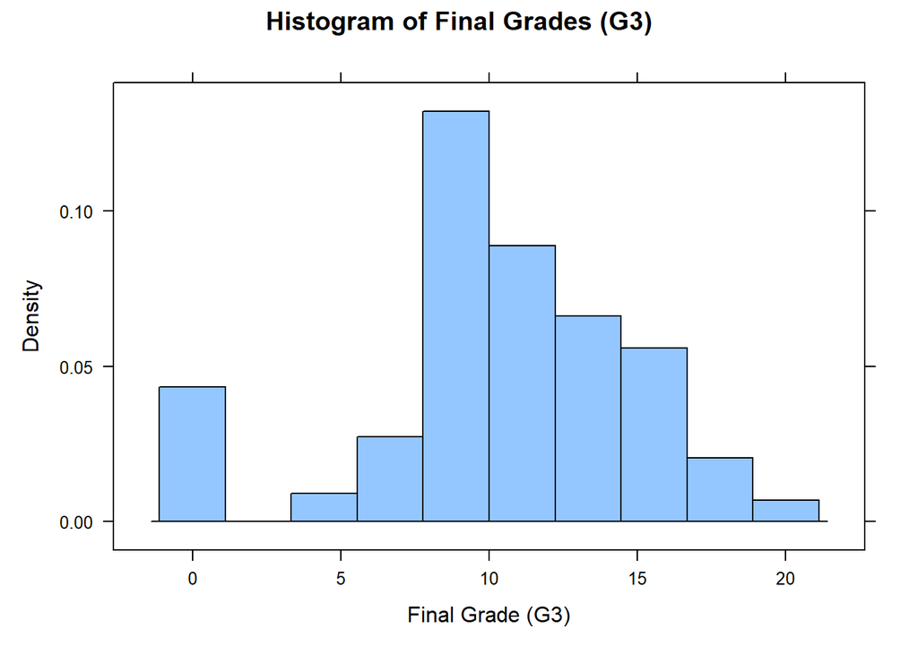

```r
histogram(student$G3, main = "Histogram of Final Grades (G3)", xlab = "Final Grade (G3)")
```

What do you notice about the shape of the distribution?  
_It looks roughly normal with a slight left skew for the people who got zeros.__

What anomalies, if any, do you notice?  
**I see that an unusual amount of people got zeros.**

Calculate summary statistics for the response variable.

```r
summary_stats <- favstats(student$G3)
summary_stats
```

```
 min Q1 median Q3 max     mean       sd   n missing
   0  8     11 14  20 10.41519 4.581443 395       0
```

What is the minimum?  
**0**

What is the maximum?  
**20**

How many students participated in the survey?  
**395**

Rank order the top 5 explanatory variables you think most influence the response and identify each as a categorical or quantitative variable:

1. **studytime - quantitative**
2. **absences - quantitative**
3. **schoolsup - quantitative**
4. **health - categorical**
5. **failures - quantitative**

**NOTE**: Some of the above variables may be quantitative, which is great! Next unit will cover how to analyze those relationships. This assignment, however, focuses on comparing differences between groups and only considers categorical explanatory variables variables.

# Preparing data for analysis

## Categories Labeled as Numbers

Sometimes even correct data can have issues that must be addressed. For example, categories are often labeled as numbers. Software can’t guess when numbers are supposed to be categories, so we have to tell R when a number should be treated as a category.

To force a variable to be a category, we use the `factor()` function in R. We can change the variable type in the data itself or change it in the analysis. We demonstrate both methods below.

### Changing a Column Type in a dataset

Father’s education, `Fedu`, shows up as a number in R. The website suggests that the numbers represent categories (0 = none, 1 = primary education (4th grade), 2 = 5th to 9th grade, 3 = secondary education or 4 = higher education).

To change the data type in the data itself, we can use a mutate statement in the following manner:

```r
# Create a new dataset called fedu_data that begins with the clean data and adds a column that we called Fedu_factor, which is the factorized column, Fedu:

new_data <- student %>%
  mutate(Fedu_factor = factor(Fedu))

# Check the column names of the new dataset.  Notice the new column
names(new_data)

# glimpse() shows us data types.  Notice after Fedu_factor, the <fct>, which shows us that this is in fact, a factor variable type.  <dbl> stands for "double" and is a numeric variable type

glimpse(new_data)
```

[output not shown]

### Changing the Variable Type “on the fly”

You may not want to bother changing all the variable types for each potential analysis. Fortunately, you can create a factor “on the fly” within the analysis function itself.

Because there are more than 2 levels of Father’s Education, I will demonstrate how this is done in an ANOVA:

```r
# Force Fedu to be treated like a category in ANOVA:
fedu_anova <- aov(student$G3 ~ factor(student$Fedu))

summary(fedu_anova)
```

```
                      Df Sum Sq Mean Sq F value Pr(>F)
factor(student$Fedu)   4    238   59.53   2.891 0.0222 *
Residuals            390   8032   20.59
---
Signif. codes:  0 '***' 0.001 '**' 0.01 '*' 0.05 '.' 0.1 ' ' 1
```

This works with most analysis functions including `t.test()` and `aov()`.

**NOTE**: You only have to do this for variables in a dataset that are categories labeled as numbers. If the categories are text, `t.test()` and `aov()` automatically recognizes the variable as categorical. However, it does no harm to put a column with text into a `factor()` statement.

## Cleaning the Data

While exploring the data, you may have noticed a few students ended up with a final grade of zero. While it may be interesting to explore what factors lead to an incomplete grade, we want to make conclusions about students who completed the course.

Create a clean dataset called, `clean`, that excludes zeros for G3. This will be used for the following analyses.

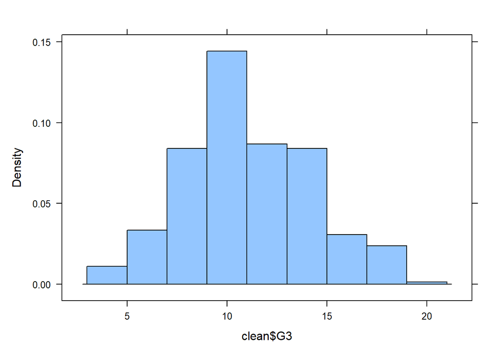

```r
clean <- student %>% filter(G3 != 0)
histogram(clean$G3)
```

# Perform the Appropriate Analysis

## Comparing Schools

Suppose the Gabriel Pereira school (GP) has more stringent admissions requirements. We suspect this would lead to higher grades, on average.

Create a side-by-side boxplot of the final grades for each school. Change the y-axis label to read “Final Grade out of 20”, the x-axis label to read “School”, and add a title.

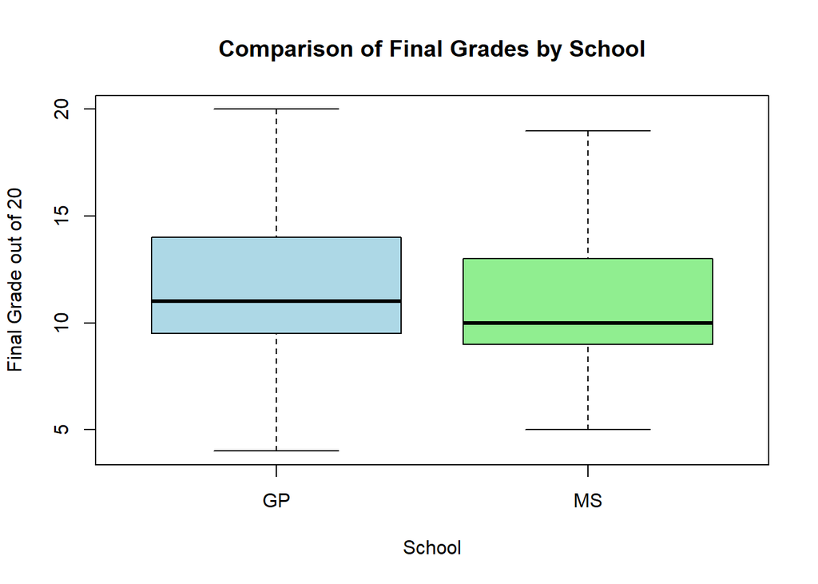

```r
boxplot(G3 ~ school, data = clean,
        main = "Comparison of Final Grades by School",
        xlab = "School",
        ylab = "Final Grade out of 20",
        col = c("lightblue", "lightgreen"))
```

What do you notice?  
**GP’s median G3 is slightly higher than MS.**

Create a table of summary statistics of final grade for each school:

```r
summary_stats_school <- clean %>%
  group_by(school) %>%
  summarize(
    Min = min(G3),
    Q1 = quantile(G3, 0.25),
    Median = median(G3),
    Mean = mean(G3),
    Q3 = quantile(G3, 0.75),
    Max = max(G3),
    SD = sd(G3),
    n = n()
  )

summary_stats_school
```

```
# A tibble: 2 × 9
  school   Min    Q1 Median  Mean    Q3   Max    SD     n
  <chr>  <dbl> <dbl>  <dbl> <dbl> <dbl> <dbl> <dbl> <int>
1 GP         4   9.5     11  11.6    14    20  3.24   315
2 MS         5   9       10  10.8    13    19  3.06    42
```

### Hypothesis Test

Create a qqPlot to look at the normality of both groups:

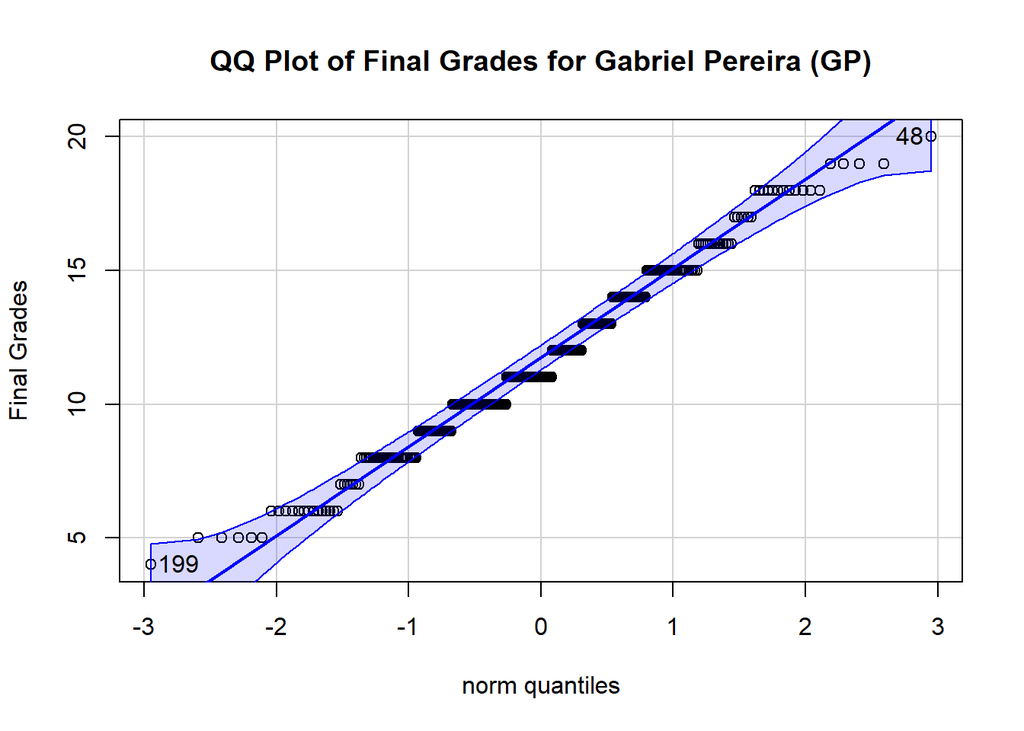

```
[1]  48 199
```

```r
qqPlot(clean$G3[clean$school == "GP"], main = "QQ Plot of Final Grades for Gabriel Pereira (GP)", ylab = "Final Grades")
```

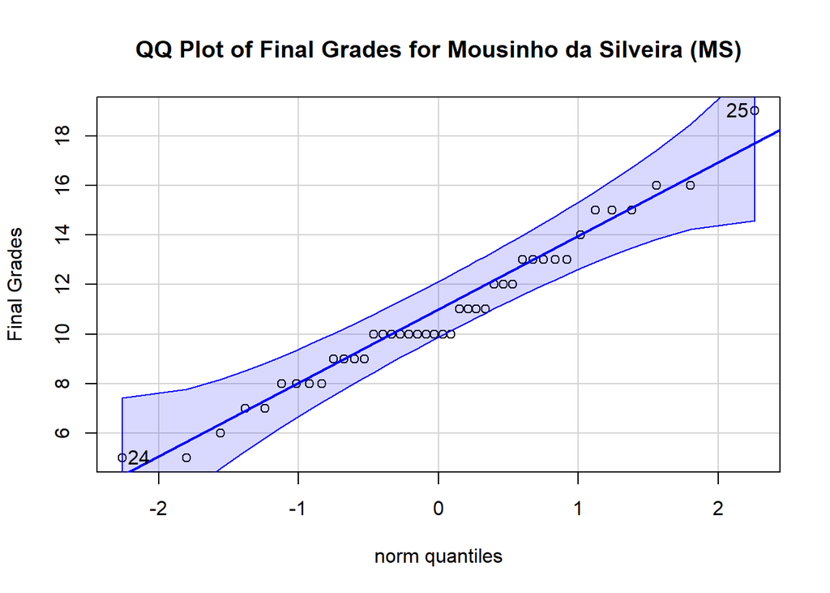

```
[1] 25 24
```

```r
qqPlot(clean$G3[clean$school == "MS"], main = "QQ Plot of Final Grades for Mousinho da Silveira (MS)", ylab = "Final Grades")
```

Do the grades look normally distributed for both groups? If not, should we be concerned? Can we trust the P-value?  
**The grades look normally distributed. We can trust the P-value.**

State your null and alternative hypotheses and significance level.

**NOTE**: Recall that R uses alphabetical order to determine which group is the reference group. It is useful to put this group on the left side of the null hypothesis and set your alternative hypothesis accordingly.

$$H_o: \mu_{GP} = \mu_{MS}$$
$$H_a: \mu_{GP} \ne \mu_{MS}$$

$\alpha = 0.05$

```r
t_test_result <- t.test(G3 ~ school, data = clean)

t_test_result
```

```
    Welch Two Sample t-test

data:  G3 by school
t = 1.6539, df = 54.062, p-value = 0.1039
alternative hypothesis: true difference in means between group GP and group MS is not equal to 0
95 percent confidence interval:
 -0.1775092  1.8505250
sample estimates:
mean in group GP mean in group MS
        11.62222         10.78571
```

What is the P-value?  
**p-value = 0.1039**

What is your conclusion in context of the research question?  
**Since the p-value is greater than the significance level, we fail to reject the null hypothesis. This indicates that there is no significant difference in the average final grades between students from Gabriel Pereira (GP) and Mousinho da Silveira (MS) schools.**

### Confidence Interval

Create a $(1-\alpha)$% confidence interval and explain it in context of the research question.

```r
conf_int <- t_test_result$conf.int
conf_int
```

```
[1] -0.1775092  1.8505250
attr(,"conf.level")
[1] 0.95
```

**The 95% confidence interval suggests that the true difference in means could be anywhere from slightly lower to moderately higher for Gabriel Pereira compared to Mousinho da Silveira. However, because the interval includes 0, we do not have strong evidence to conclude that there is a significant difference in average final grades between the two schools.**

## Comparing Second Period Grade with Final Grade

We suspect there is a difference between the second period and the final grade, though we do not know if they go up or down. Carry out a hypothesis test to evaluate this suspicion.

### Hypothesis Test

Choose how you will define the difference between final grade and second period grade, and create a new object called `diff`:

```r
diff <- clean$G3 - clean$G2
```

What does a negative number mean?  
**A negative number in diff means that the final grade (G3) is lower than the second period grade (G2), indicating a decline in performance from the second period to the final.**

Create a qqPlot of `diff` and check for normality:

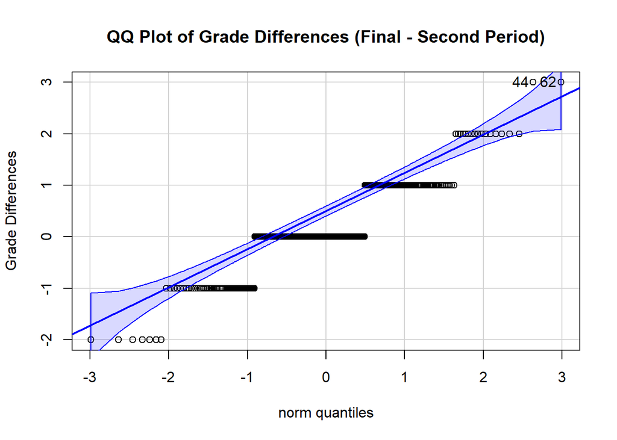

```
[1] 44 62
```

```r
qqPlot(diff, main = "QQ Plot of Grade Differences (Final - Second Period)", ylab = "Grade Differences")
```

Do the grade differences look normally distributed? If not, should we be concerned? Can we trust the P-value?  
**No the grades differences do not look normally distributed but there are more than 30 samples.**

State your null and alternative hypothesis and choose a significance level:

$$H_0: \mu_d = 0$$

Perform the appropriate analysis.

```r
t_test_results <- t.test(diff, mu = 0, alternative = "two.sided")

t_test_results
```

```
    One Sample t-test

data:  diff
t = 3.717, df = 356, p-value = 0.0002341
alternative hypothesis: true mean is not equal to 0
95 percent confidence interval:
 0.07782404 0.25270817
sample estimates:
mean of x
0.1652661
```

What is the P-value?  
**p-value = 0.0002341**

What conclusion do you make in context of this research question?  
**Since the p-value is less than the significance level, we reject the null hypothesis. This indicates that there is a significant difference between the second period grade and the final grade.**

### Confidence Interval

Create a $(1-\alpha)$% confidence interval for the differences and explain it in context of the research question.

```r
conf_int <- t_test_results$conf.int
conf_int
```

```
[1] 0.07782404 0.25270817
attr(,"conf.level")
[1] 0.95
```

**This 95% confidence interval indicates that we are 95% confident that the true mean difference between the final grades (G3) and the second period grades (G2) lies between approximately 0.078 and 0.253.**

## Absenteeism in Portugal

In 2021, Portugal [reported](https://ec.europa.eu/eurostat/statistics-explained/index.php?title=Secondary_education_statistics#Out-of-school_rates) having 0% absenteeism for 15-year-olds. We suspect that the actual absenteeism is higher than the reported value (zero).

### Hypothesis Test

Create a qqPlot for absences.

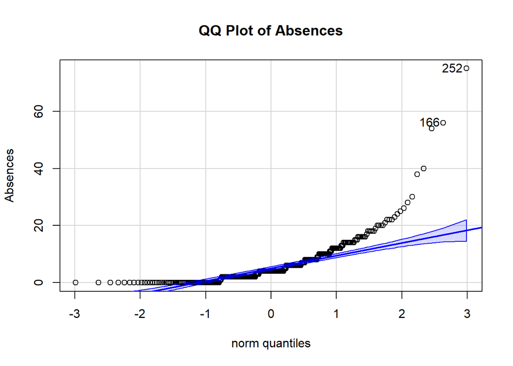

```
[1] 252 166
```

```r
qqPlot(clean$absences, main = "QQ Plot of Absences", ylab = "Absences")
```

State your null and alternative hypotheses and choose a significance level:

$$H_0: \mu = 0$$

$\alpha = 0.05$

Perform the appropriate analysis.

```r
t_test_absences <- t.test(clean$absences, mu = 0, alternative = "greater")

t_test_absences
```

```
    One Sample t-test

data:  clean$absences
t = 14.577, df = 356, p-value < 2.2e-16
alternative hypothesis: true mean is greater than 0
95 percent confidence interval:
 5.601894      Inf
sample estimates:
mean of x
 6.316527
```

State your conclusion in context of the research question.  
**Since the p-value is less than 0.05, we reject the null hypothesis. This indicates that the mean number of absences is significantly greater than zero, suggesting that the actual absenteeism is higher than the reported value of zero for 15-year-olds in Portugal.**

### Confidence Interval

Create a $(1-\alpha)$% confidence interval for average absences and interpret it in context of the problem.

```r
conf_int_absences <- t_test_absences$conf.int
conf_int_absences
```

```
[1] 5.601894      Inf
attr(,"conf.level")
[1] 0.95
```

**This confidence interval indicates that we are 95% confident that the true mean number of absences for 15-year-olds in Portugal is greater than approximately 5.602. This suggests that the actual absenteeism rate is significantly higher than the reported value of zero.**

## The Impact of Mother’s Education Level

The level of education of the mother in the home is thought to have a significant impact on student success.

Create a side-by-side boxplot of final grades for each level of mother’s education.

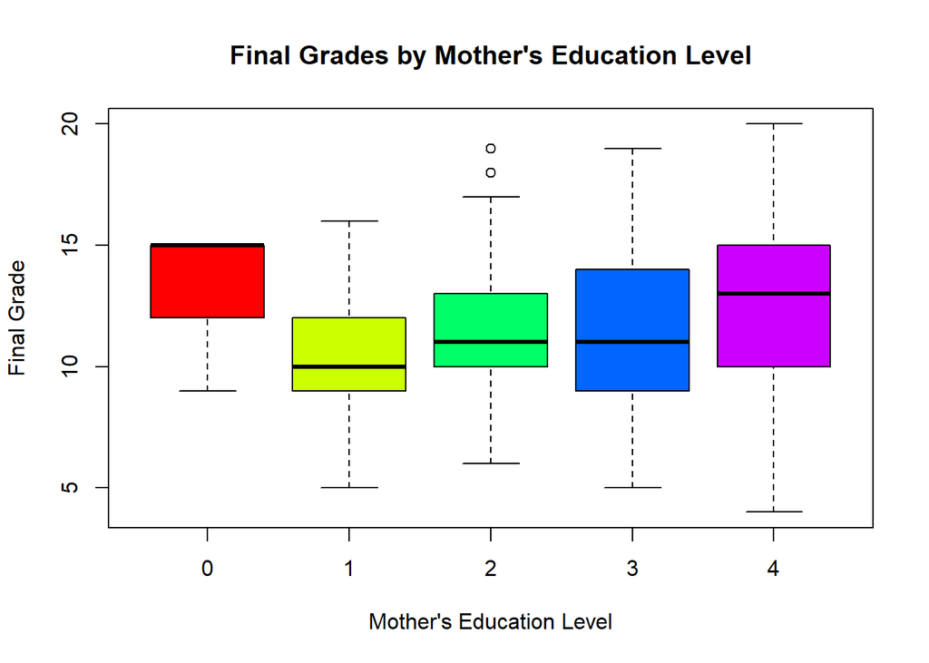

```r
boxplot(G3 ~ factor(Medu), data = clean, main = "Final Grades by Mother's Education Level",
        xlab = "Mother's Education Level", ylab = "Final Grade", col = rainbow(5))
```

Create a table of summary statistics of final grades for each level of mother’s education.

```r
summary_stats_medu <- clean %>%
  group_by(factor(Medu)) %>%
  summarize(
    Min = min(G3),
    Q1 = quantile(G3, 0.25),
    Median = median(G3),
    Mean = mean(G3),
    Q3 = quantile(G3, 0.75),
    Max = max(G3),
    SD = sd(G3),
    n = n()
  )

summary_stats_medu
```

```
# A tibble: 5 × 9
  `factor(Medu)`   Min    Q1 Median  Mean    Q3   Max    SD     n
  <fct>          <dbl> <dbl>  <dbl> <dbl> <dbl> <dbl> <dbl> <int>
1 0                  9    12     15  13    15      15  3.46     3
2 1                  5     9     10  10.2  12      16  2.50    50
3 2                  6    10     11  11.3  13      19  2.74    89
4 3                  5     9     11  11.3  13.8    19  3.42    90
5 4                  4    10     13  12.3  15      20  3.48   125
```

How many respondents have a mother with no formal education (level 0)?  
**3**

Create a new dataset, `clean_medu`, that does not include mother’s education level 0.

```r
# clean_medu <- clean %>%
clean_medu <- clean %>% filter(Medu != 0)
```

Create another boxplot with the new dataset that excludes level 0.

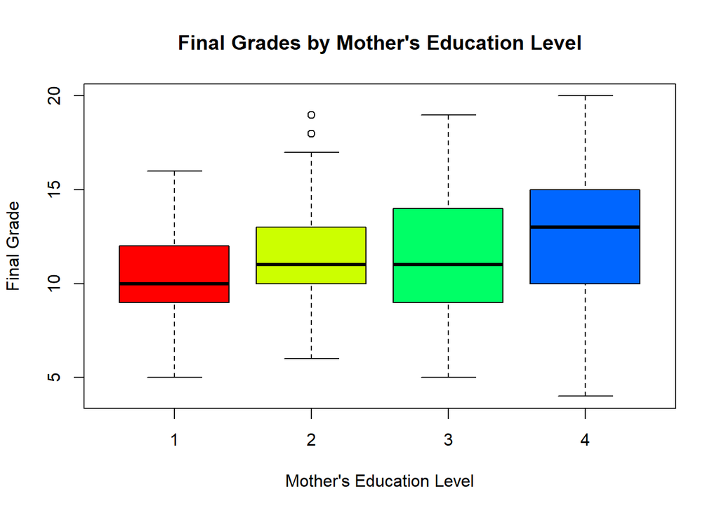

```r
boxplot(G3 ~ factor(Medu), data = clean_medu, main = "Final Grades by Mother's Education Level",
        xlab = "Mother's Education Level", ylab = "Final Grade", col = rainbow(5))
```

Create a summary table of final grades for each level of a mother’s education with the new dataset.

```r
summary_stats_medu <- clean_medu %>%
  group_by(factor(Medu)) %>%
  summarize(
    Min = min(G3),
    Q1 = quantile(G3, 0.25),
    Median = median(G3),
    Mean = mean(G3),
    Q3 = quantile(G3, 0.75),
    Max = max(G3),
    SD = sd(G3),
    n = n()
  )


summary_stats_medu
```

```
# A tibble: 4 × 9
  `factor(Medu)`   Min    Q1 Median  Mean    Q3   Max    SD     n
  <fct>          <dbl> <dbl>  <dbl> <dbl> <dbl> <dbl> <dbl> <int>
1 1                  5     9     10  10.2  12      16  2.50    50
2 2                  6    10     11  11.3  13      19  2.74    89
3 3                  5     9     11  11.3  13.8    19  3.42    90
4 4                  4    10     13  12.3  15      20  3.48   125
```

What is the maximum standard deviation?  
**3.475202**

What is the minimum standard deviation?  
**2.495383**

Verify that the maximum is less than twice as large as the minimum to check the “equality of standard deviations”.

```r
max_sd <- max(summary_stats_medu$SD)
min_sd <- min(summary_stats_medu$SD)


max_sd_less_than_twice_min_sd <- max_sd < 2 * min_sd


cat("Maximum standard deviation:", max_sd, "\n")
```

```
Maximum standard deviation: 3.475202
```

```r
cat("Minimum standard deviation:", min_sd, "\n")
```

```
Minimum standard deviation: 2.495383
```

```r
cat("Is the maximum SD less than twice the minimum SD?:", max_sd_less_than_twice_min_sd, "\n")
```

```
Is the maximum SD less than twice the minimum SD?: TRUE
```

### Hypothesis Test

State your null and alternative hypotheses and pick alpha:

$\alpha = 0.05$

Perform the appropriate statistical test.

```r
anova_result <- aov(G3 ~ Medu, data = clean)

summary(anova_result)
```

```
             Df Sum Sq Mean Sq F value   Pr(>F)
Medu          1    134  134.33   13.34 0.000299 ***
Residuals   355   3575   10.07
---
Signif. codes:  0 '***' 0.001 '**' 0.01 '*' 0.05 '.' 0.1 ' ' 1
```

What is the test statistic?  
**13.34**

What is the P-value?  
**0.000299**

Check the normality of the residuals.

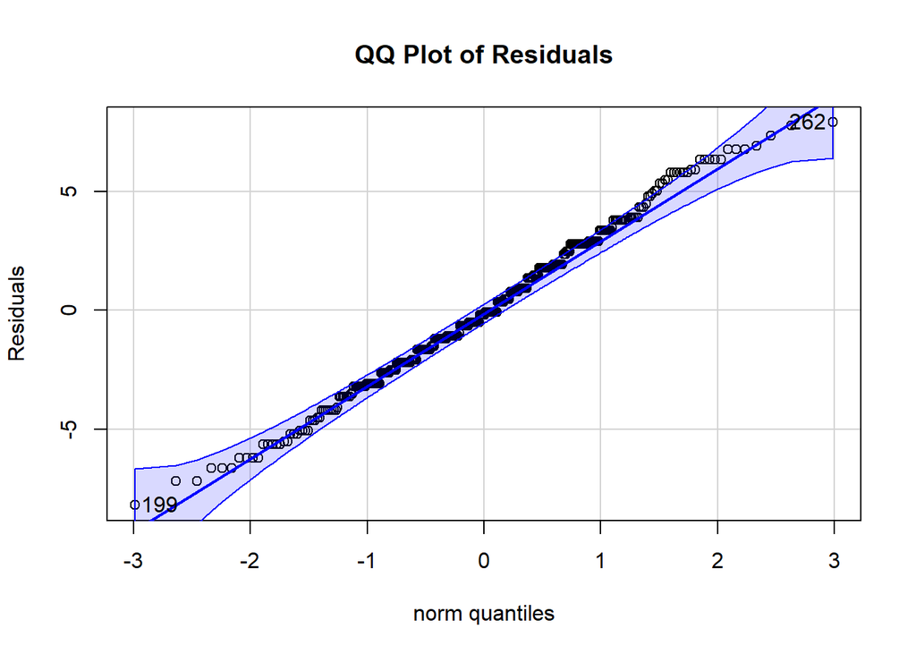

```
[1] 199 262
```

```r
qqPlot(anova_result$residuals, main = "QQ Plot of Residuals", ylab = "Residuals")
```

Do the residuals appear roughly normally distributed?  
**Yes**

Can we trust the P-value.  
**Yes**

## Choose your own adventure

Pick another variable that was not analyzed above.

Create a side-by-side boxplot. Be sure to properly label the graph and add sufficient information so readers can know what they are looking at without having to search through the report or code.

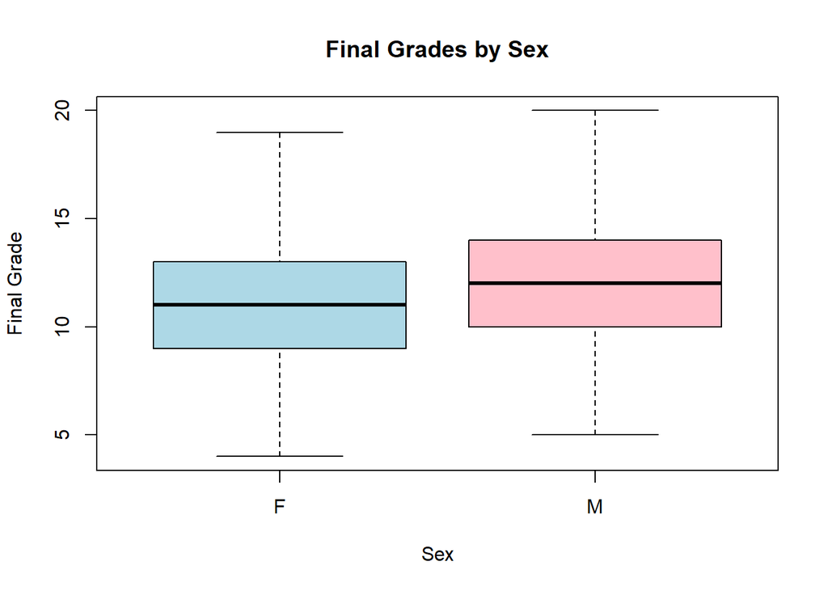

```r
boxplot(G3 ~ sex, data = clean, main = "Final Grades by Sex",
        xlab = "Sex", ylab = "Final Grade", col = c("lightblue", "pink"))
```

```r
summary_stats_sex <- clean %>%
  group_by(sex) %>%
  summarize(
    Min = min(G3),
    Q1 = quantile(G3, 0.25),
    Median = median(G3),
    Mean = mean(G3),
    Q3 = quantile(G3, 0.75),
    Max = max(G3),
    SD = sd(G3),
    n = n()
  )

summary_stats_sex
```

```
# A tibble: 2 × 9
  sex     Min    Q1 Median  Mean    Q3   Max    SD     n
  <chr> <dbl> <dbl>  <dbl> <dbl> <dbl> <dbl> <dbl> <int>
1 F         4     9     11  11.2    13    19  3.17   185
2 M         5    10     12  11.9    14    20  3.26   172
```

$$H_o: \mu_{m} = \mu_{f}$$
$$H_a: \mu_{m} \ne \mu_{f}$$
$\alpha = 0.05$

Perform the appropriate analysis. Be sure to include a concise conclusion in the context of the research question, including a hypothesis test (and confidence interval if applicable.)

```r
t_test_sex <- t.test(G3 ~ sex, data = clean)

t_test_sex
```

```
    Welch Two Sample t-test

data:  G3 by sex
t = -1.9386, df = 351.54, p-value = 0.05335
alternative hypothesis: true difference in means between group F and group M is not equal to 0
95 percent confidence interval:
 -1.331331307  0.009583978
sample estimates:
mean in group F mean in group M
       11.20541        11.86628
```

**Since the p-value is greater than the significance level, we fail to reject the null hypothesis. This indicates that there is no statistically significant difference in the final grades between male and female students.**